# Reproducible Research Proj 1

Mary Ann D

Saturday, July 18, 2015

This is an R Markdown document.

```r
library(knitr)
library(ggplot2)
library(lattice)
opts_chunk$set(fig.width=10,fig.height=6, echo=TRUE, fig.path="Figs/")
setwd("C:/Coursera/Class5RepResearch/Proj1")
fileUrl<- "activity.csv"
```

## Load and preprocess the data

```r
actdat <- read.csv("activity.csv", header=TRUE,colClasses = c("integer", "Date", "factor"))
noNA <- na.omit(actdat)
rownames(noNA) <- 1:nrow(noNA)
```

## What is mean total number of steps taken per day?

1. Calculate the total number of steps taken per day

```r
totsteps <- aggregate(steps ~ date, data=noNA, sum, na.rm=TRUE)
```

2. Make a histogram of the total number of steps taken each day

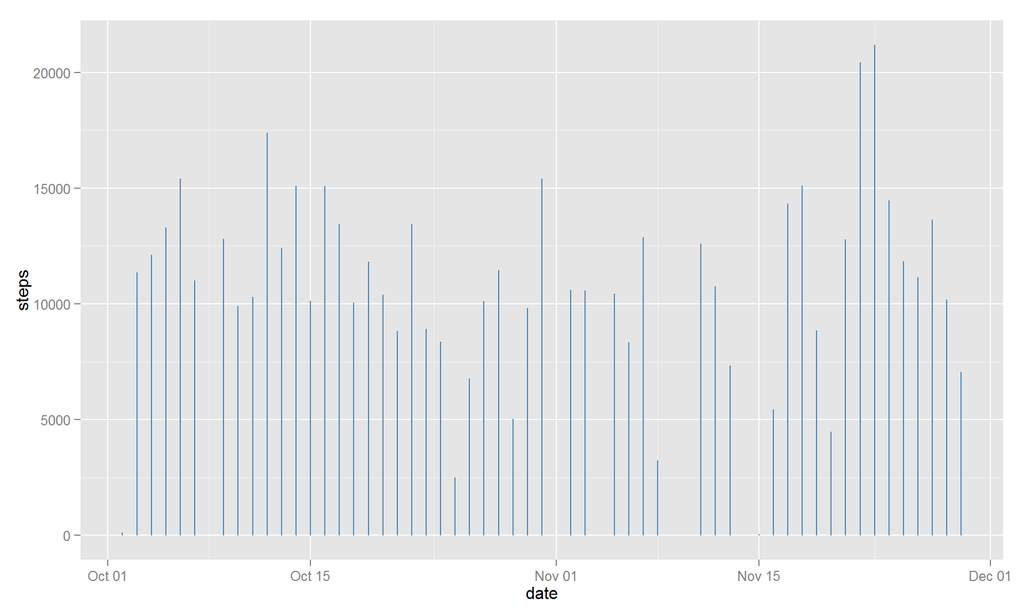

```r
ggplot(noNA, aes(date, steps)) + geom_bar(stat = "identity", colour = "steelblue", fill = "steelblue", width = 0)
```

```r
meanSteps<- mean(totsteps$steps)
medianSteps<- median(totsteps$steps)
```

## What is the average daily activity pattern?

1. Make a time series plot (i.e. type = “l”) of the 5-minute interval (x-axis) and the average number of steps taken, averaged across all days (y-axis)

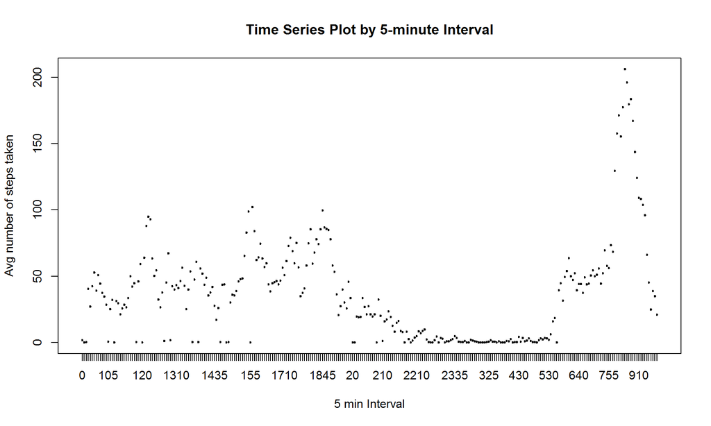

```r
intervaldat <- aggregate(steps ~ interval, data=actdat, mean, na.rm=TRUE)
plot (steps~interval, data=intervaldat, type="l", main="Time Series Plot by 5-minute Interval", xlab="5 min Interval",ylab="Avg number of steps taken")
```

2. Which 5-minute interval, on average across all the days in the dataset, contains the maximum number of steps?

```r
maxinterval <- intervaldat[which.max(intervaldat$steps),]
maxinterval$interval
```

```
## [1] 835
## 288 Levels: 0 10 100 1000 1005 1010 1015 1020 1025 1030 1035 1040 ... 955
```

## Inputing missing values

1. Calculate and report the total number of missing values in the dataset (i.e. the total number of rows with NAs)

```r
missingvals <- sum(is.na(actdat$steps))
```

```
The total numberof rows with missing values is 2304
```

2. Devise a strategy for filling in all of the missing values in the dataset.

Strategy used is to replace missing values with the mean of each interval calculated above.

3. Create a new dataset that is equal to the original dataset but with the missing data filled in.

```r
newdat<- actdat
for (i in 1:nrow(newdat)) {
   if (is.na(newdat$steps[i])) {
      newdat$steps[i] <- intervaldat[which(newdat$interval[i] == intervaldat$interval),]$steps
   }
}
### Recreate the new data with all the data filled in
totalStepsNew<-aggregate(steps ~ date, data=newdat, sum)
```

4. Make a histogram of the total number of steps taken each day.

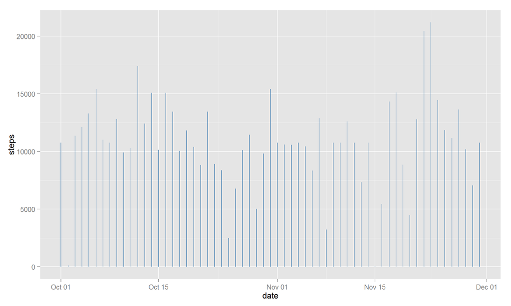

```r
ggplot(totalStepsNew, aes(date, steps)) + geom_bar(stat = "identity", colour = "steelblue", fill = "steelblue", width = 0)
```

```r
meanStepsNew<-mean(totalStepsNew$steps)
medianStepsNew<-median(totalStepsNew$steps)
```

Calculate and report the mean and median total number of steps taken per day. Do these values differ from the estimates from the first part of the assignment? What is the impact of inputing missing data on the estimates of the total daily number of steps?

[output not shown]

## Are there differences in activity patterns between weekdays and weekends?

1. Create a new factor variable in the dataset with two levels - “weekday” and “weekend” indicating whether a given date is a weekday or weekend day.

```r
### Format field as a date field
newdat$date<-as.Date(newdat$date,format="%Y-%m-%d")
## Add new column to include the day of week
newdat$day<-weekdays(newdat$date)
### Add another column to indicate day or end and Initialize column to 'weekday'
newdat$dayType<-c("Weekday")
## Assign the day of week with For Loop
for(i in 1:nrow(newdat)){
   if (newdat$day[i]=="Saturday" || newdat$day[i]=="Sunday"){
      newdat$dayType[i]<-"Weekend" } }
```

2. Make a panel plot containing a time series plot (i.e. type = “l”) of the 5-minute interval (x-axis) and the average number of steps taken, averaged across all weekday days or weekend days (y-axis).

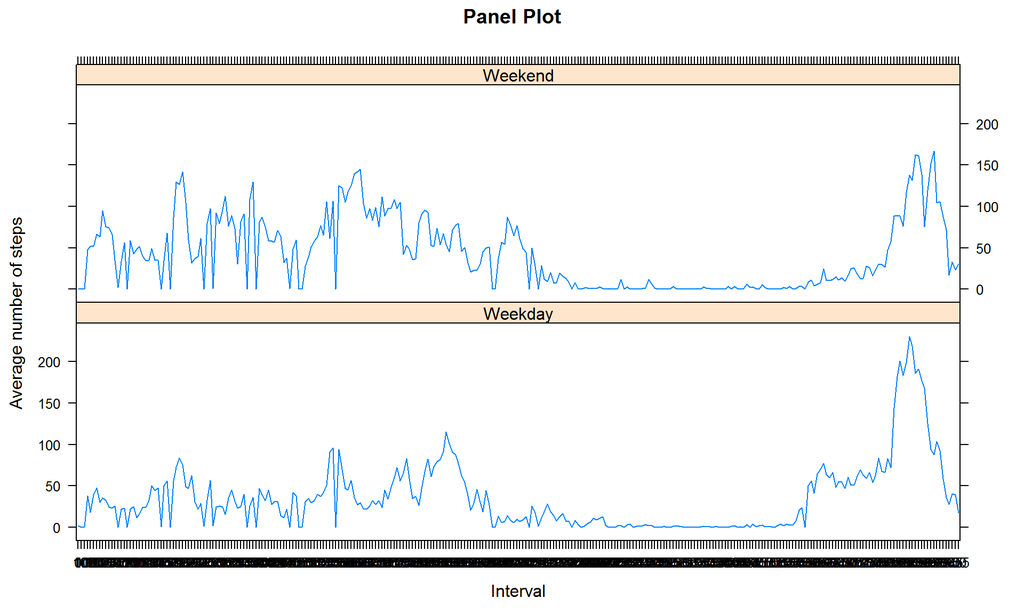

```r
intervalDatNew<-aggregate(steps ~ interval + dayType, data=newdat, mean)
xyplot(steps ~ interval|factor(dayType), data=intervalDatNew,
       type="l",layout=c(1,2),main="Panel Plot", xlab="Interval",ylab="Average number of steps")
```